# *Learning about Bias?* An Experiment on Paying Attention to News in Russia

Georgiy Syunyaev

g.syunyaev@vanderbilt.edu

Vanderbilt University, WZB Berlin

Anton Shirikov

shirikov@ku.edu

University of Kansas

## Motivation

- Hard propaganda $\Rightarrow$ Informational autocrats using biased media
- Most people consume news from outlets that are biased
  - This can mean *fake news*, selection, or framing
  - More likely in autocracies with state control of the media environment
- But often they misunderstand or underestimate media bias
- **Question** Can we make citizens learn about media bias?
- …Does this lead to switching to less biased media, and changes in political attitudes?

## How can we answer the question

- **Dual-processing theory:** Type 1 processing – automaticity and cue, and Type 2 processing – deliberation
- **Media literacy:** Activate Type 2 processing via innoculation or prebunking interventions to improve ability to discern biased or false information
  - Can fail or even backfire, e.g. due to motivated reasoning
- **Attentiveness prompts:** Ask citizens about important characteristics of information (e.g. whether it is accurate)
  - But propaganda or biased media does not always lie
- We combine approaches and try to make citizens learn about propaganda media *on their own*

## Our approach

Ask citizens to analyze the topics and sentiment of news headlines by state and *(in addition)* independent media

*…to test whether…*

Paying attention to what media outlet covers make citizens:

1. Learn about media coverage patterns (positive domestic and negative foreign)
2. Change perceptions media outlet’s bias (state is more biased)
3. Adjust media consumption (away from state media)
4. Change political attitudes (more critical of government / policies)

## Setting and design

- Russia: an autocratic regime with state control of media environment
  - The full-scale invasion in Ukraine exacerbated state media control
  - State media is heavily pro-government (main mouthpiece is *Rossiya-1*)
  - Some *more* critical media is still available (e.g. *RTVI*)

  **$\Rightarrow$ Harder to shift media beliefs and consumption**
- Study:
  - 4-wave online panel experiment among adult Russian citizens (2037 in wave 1 $\Rightarrow$ 1176 in wave 4) enrolled in online panel
  - Simple random assignment to one of *three* experimental groups with different sets of tasks
  - Content-analysis tasks at the end of survey in waves 1-3 $\Rightarrow$ more than 2 weeks between tasks and outcome measurement
  - Analyses focus on the endline outcomes

## Intervention

- Watch 4 to 6 short news headline segments per wave from one of three TV channels:
  - *Kultura*, a non-political TV channel that covers art, theater, architecture, etc.
  - *Rossiya-1*, the main state-controlled propaganda channel
  - *RTVI*, a privately owned TV channel with moderately critical editorial policy

## Experimental conditions

- **Placebo:** Kultura (Date 1) $\Rightarrow$ Kultura (Date 2) $\Rightarrow$ Kultura (Date 3) $\Rightarrow$ Kultura (Date 4) …
- **State:** Rossiya-1 (Date 1) $\Rightarrow$ Kultura (Date 1) $\Rightarrow$ Rossiya-1 (Date 2) $\Rightarrow$ Kultura (Date 2) …
- **State + Independent:** Order: Rossiya-1 (Date 1) $\Rightarrow$ RTVI (Date 1) $\Rightarrow$ Rossiya-1 (Date 2) $\Rightarrow$ RTVI (Date 2) …

[video not shown]

[figure not shown]

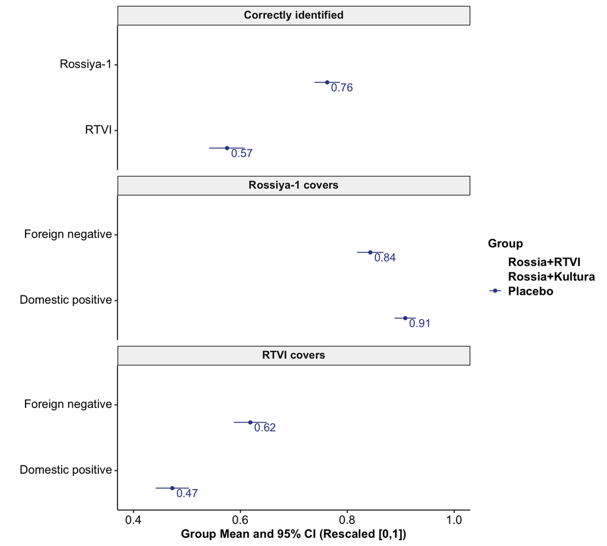

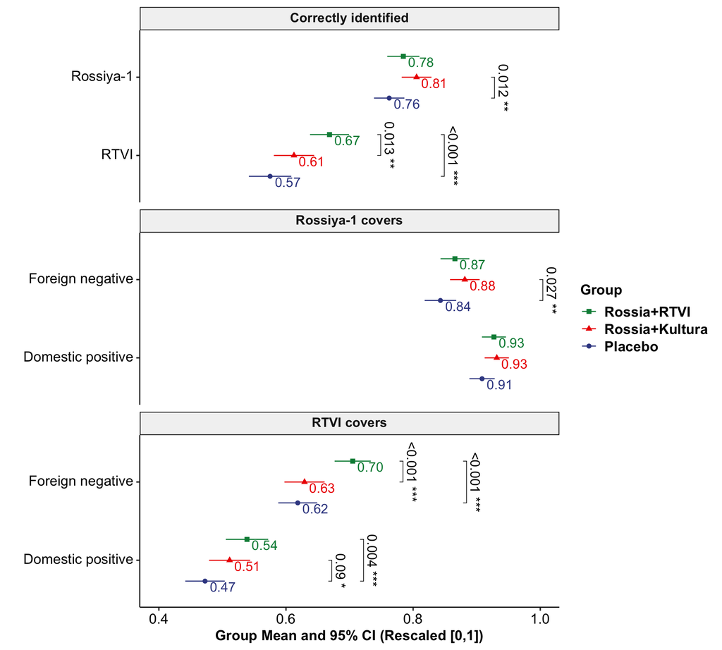

### Awareness of media coverage patterns

- More baseline uncertainty about independent media coverage
- Evidence of learning about coverage patterns
- Especially for independent media in respective group

[figure not shown]

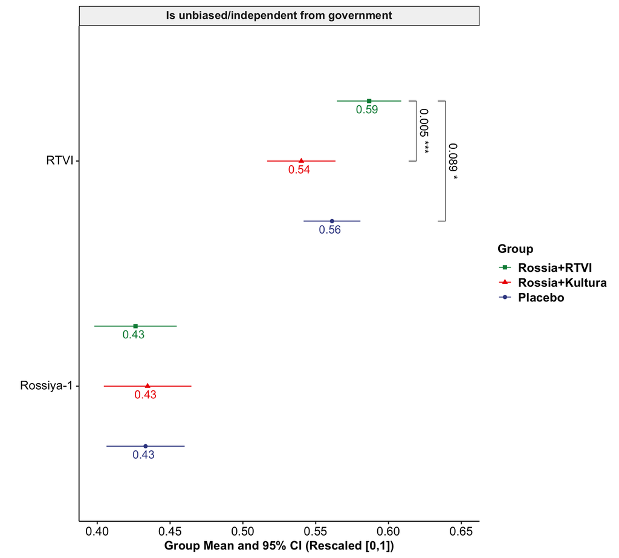

### Perceptions of media outlets

- No change in perceptions of state media
- But improved perceptions of independent media in respective group

[figure not shown]

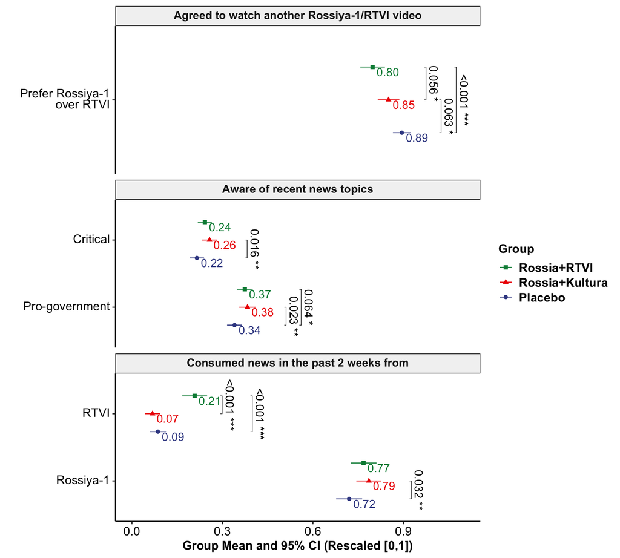

### Media consumption and preferences

- Positive shift in self-reported consumption of both Rossiya-1 and RTVI
- Stronger revealed preference for RTVI in both treatment groups
- Increased awareness of both pro-government and critical news

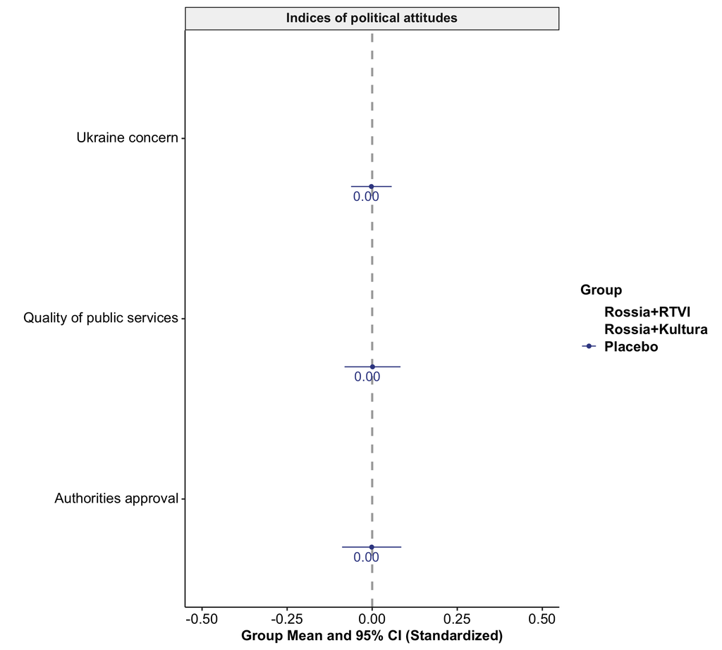

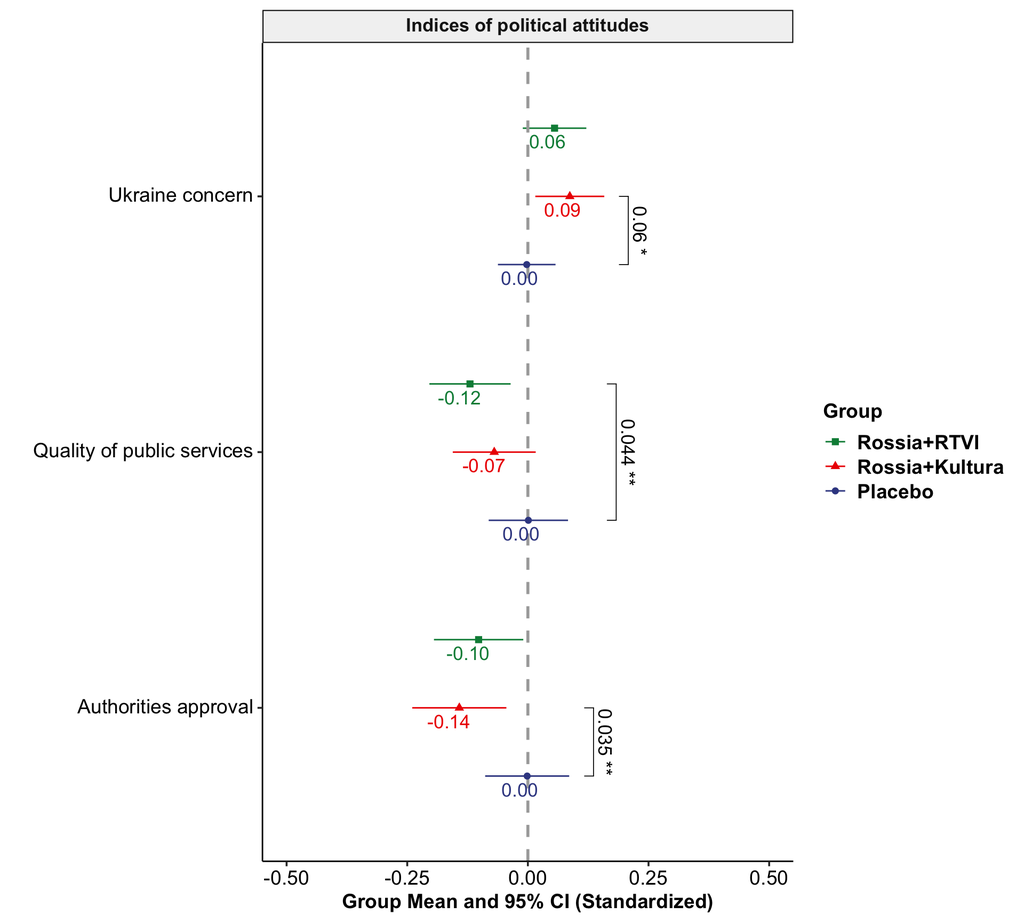

### Political attitudes

- Lower support for the government and stronger concerns about Ukraine
- No clear differences between treatment groups

[figure not shown]

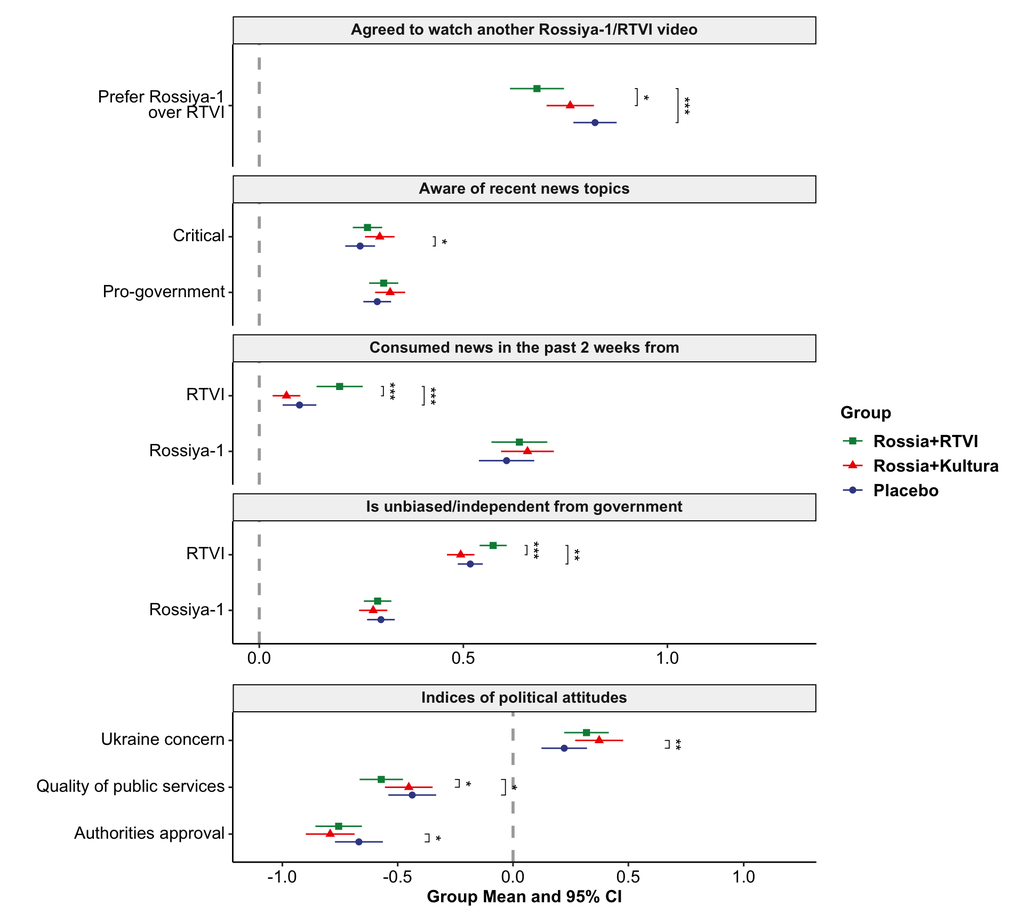

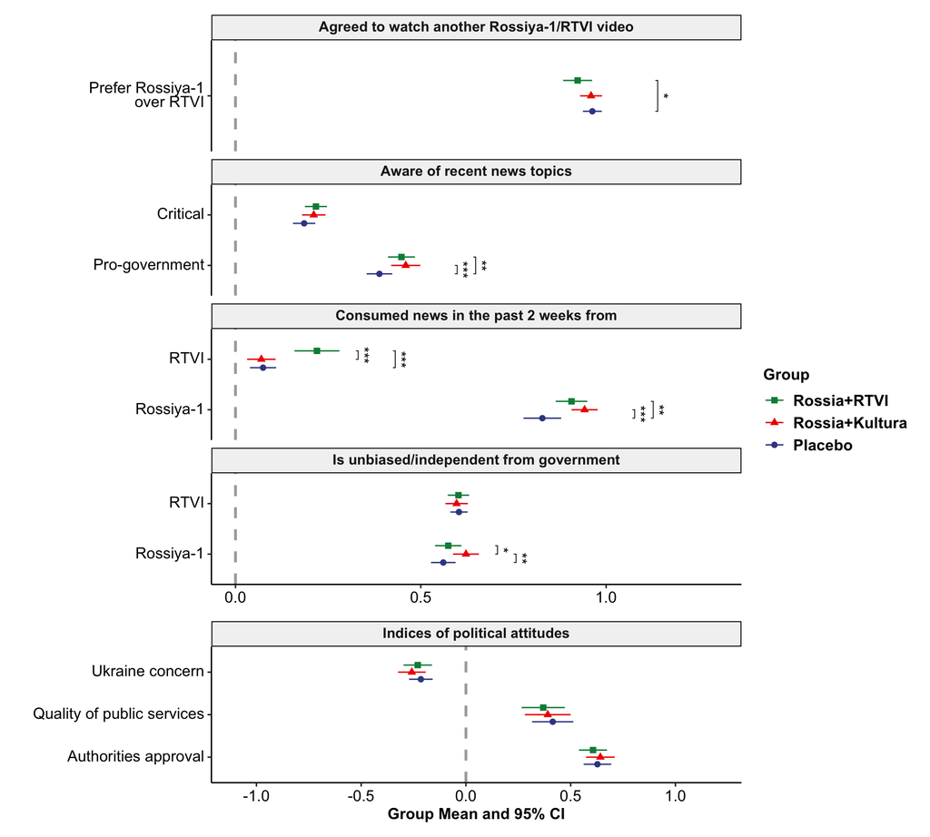

### Mechanism: Prior government approval

- **Government critics:** Increase in perceptions of unbiasedness and preferences for RTVI; Decrease in support for authorities and increase in Ukraine concerns
- **Government supporters:** Increase in consumption of Rossiya-1 and RTVI; No changes in political attitudes

## Takeaways

# Appendix

## References

## Sample characteristics

| Variable | Obs | Mean | SD | Min | p25 | p50 | p75 | Max |
| --- | --- | --- | --- | --- | --- | --- | --- | --- |
| **Socio-economic characteristics** |  |  |  |  |  |  |  |  |
| Age | 1176 | 44.81 | 12.06 | 19 | 36.00 | 45.00 | 54.00 | 80.00 |
| Female | 1175 | 0.48 | 0.50 | 0 | 0.00 | 0.00 | 1.00 | 1.00 |
| Education | 1176 | 2.55 | 0.68 | 0 | 2.00 | 3.00 | 3.00 | 3.00 |
| Income level (categorical) | 1176 | 2.82 | 0.88 | 0 | 2.00 | 3.00 | 3.00 | 5.00 |
| Employed permanently | 1176 | 0.74 | 0.44 | 0 | 0.00 | 1.00 | 1.00 | 1.00 |
| **Use of advanced Internet technologies** |  |  |  |  |  |  |  |  |
| VPN | 1050 | 0.50 | 0.50 | 0 | 0.00 | 1.00 | 1.00 | 1.00 |
| Total (out of 8) | 1176 | 3.22 | 2.13 | 0 | 2.00 | 3.00 | 5.00 | 8.00 |
| **Overall news consumption** |  |  |  |  |  |  |  |  |
| Frequency (categorical) | 1176 | 2.74 | 0.63 | 0 | 3.00 | 3.00 | 3.00 | 3.00 |
| From TV | 1142 | 0.80 | 0.40 | 0 | 1.00 | 1.00 | 1.00 | 1.00 |
| From online media | 1142 | 0.73 | 0.44 | 0 | 0.00 | 1.00 | 1.00 | 1.00 |
| **Recently consumed news** |  |  |  |  |  |  |  |  |
| From Rossiya-1 | 1175 | 0.68 | 0.47 | 0 | 0.00 | 1.00 | 1.00 | 1.00 |
| From RTVI | 1175 | 0.04 | 0.19 | 0 | 0.00 | 0.00 | 0.00 | 1.00 |
| Intensity of state media use | 1173 | 0.24 | 0.18 | 0 | 0.12 | 0.19 | 0.31 | 0.88 |
| Intensity of indep. media use | 1173 | 0.07 | 0.15 | 0 | 0.00 | 0.00 | 0.11 | 1.00 |
| **Attitudes** |  |  |  |  |  |  |  |  |
| Media in Russia unbiased | 1176 | 0.52 | 0.28 | 0 | 0.33 | 0.67 | 0.67 | 1.00 |
| Strength of preference for unbiased news | 1176 | 0.36 | 0.23 | 0 | 0.25 | 0.25 | 0.50 | 0.75 |
| President approval | 1173 | 0.60 | 0.49 | 0 | 0.00 | 1.00 | 1.00 | 1.00 |
| **Government focuses too much on** |  |  |  |  |  |  |  |  |
| Law and order | 1176 | 0.09 | 0.29 | 0 | 0.00 | 0.00 | 0.00 | 1.00 |
| Foreign affairs | 1176 | 0.12 | 0.33 | 0 | 0.00 | 0.00 | 0.00 | 1.00 |

## Concerns over the design?

- **No pure control?** No systematic evidence of Placebo (*Kultura*) group changes over time
- **Political news push respondents away?** No differences in patterns of attrition across treatment groups
- **Less attention to political news?** High and similar rates of correct answers about the topic and channel across groups
- **Experimenter demand?** No differences across treatment groups in respondents’ assessments of study goals

## Media perceptions breakdown

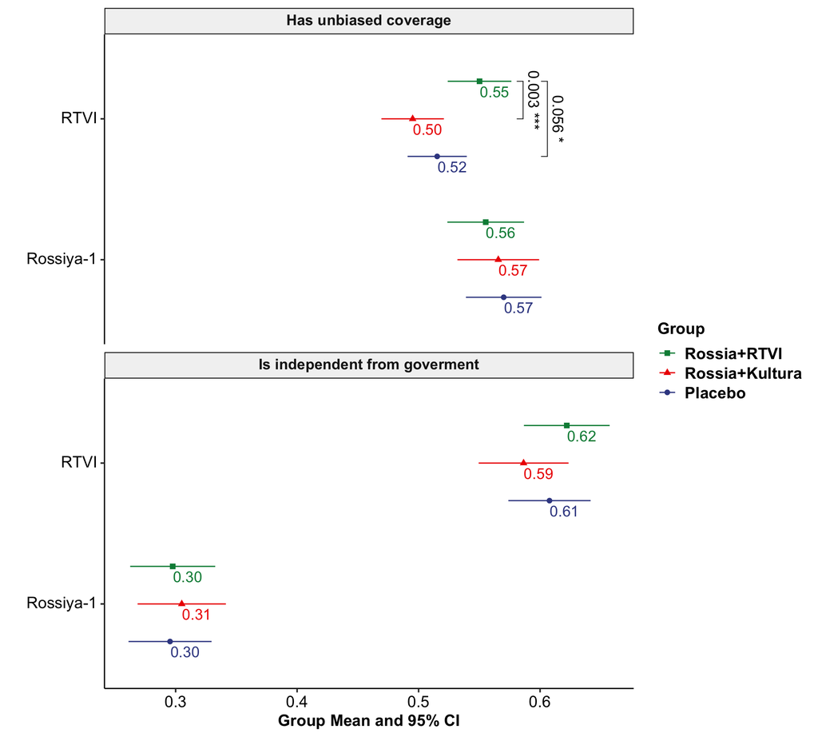

## Authorities approval breakdown

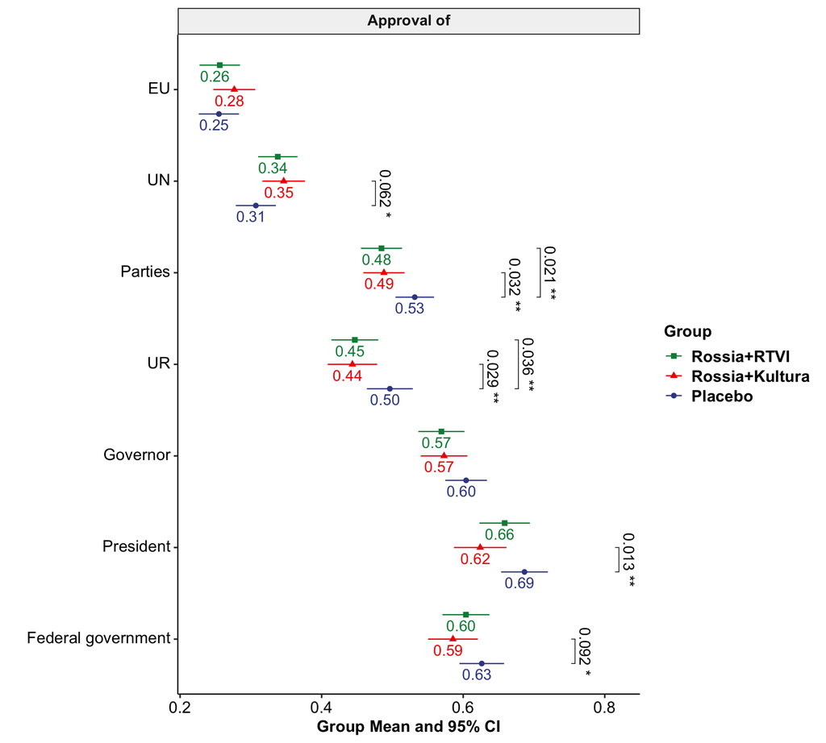

## Policy satisfaction breakdown

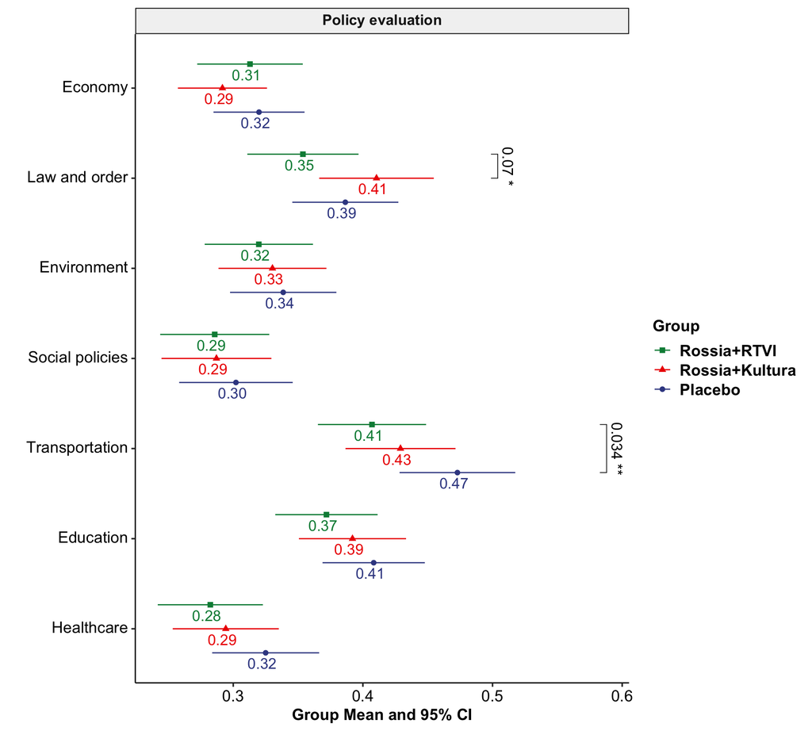

Shirikov, Syunyaev · Learning about Bias?